# Init_anal.Rmd

HallBM

2022-06-28

##Background: Weight Lifting Exercises Dataset Six young health participants were asked to perform one set of 10 repetitions of the Unilateral Dumbbell Biceps Curl in five different fashions: exactly according to the specification (Class A), throwing the elbows to the front (Class B), lifting the dumbbell only halfway (Class C), lowering the dumbbell only halfway (Class D) and throwing the hips to the front (Class E).

Class A corresponds to the specified execution of the exercise, while the other 4 classes correspond to common mistakes. Participants were supervised by an experienced weight lifter to make sure the execution complied to the manner they were supposed to simulate. The exercises were performed by six male participants aged between 20-28 years, with little weight lifting experience. We made sure that all participants could easily simulate the mistakes in a safe and controlled manner by using a relatively light dumbbell (1.25kg).

##load required libraries

```r
library(caret)
library(randomForest)
library(forecast)
```

##loading and cleaning data set

```r
#read training and test data
train = read.csv("./pml-training.csv", na.strings=c("NA","#DIV/0!",""))
test = read.csv("./pml-testing.csv", na.strings=c("NA","#DIV/0!",""))

#remove categories with NA
test = test[,colSums(is.na(test)) == 0]
train = train[,colSums(is.na(train)) == 0]
```

```r
#check to make sure categories match (i.e., were the same categories removed from each data set)
dim(test)
dim(train)
sum(colnames(test)[1:53] == colnames(train)[1:53])
#All 53 data columns match, except for column 54 (classe in training, problemID in test): everything is correct for next steps
```

[output not shown]

```r
#removal of technical variables associated with the experiment, keeping user as a factor variable
train[,c(1,3:7)] = NULL
test[,c(1,3:7)] = NULL

#set username and classe to factors
train$user_name = factor(train$user_name)
test$user_name = factor(test$user_name)
train$classe = factor(train$classe)
```

##Data modeling: A Random Forest data model was chosen to model the categorical output (dumbbell curl technique/position). This model provides internal cross-validation by constructing different bootstrap samples from the originla data during a series of simulated runs (n=500).

```r
set.seed(12345)

#randomForest
rfmod = randomForest(classe~., data = train, ntree = 500)
rfmod
```

```
##
## Call:
##  randomForest(formula = classe ~ ., data = train, ntree = 500)
##                Type of random forest: classification
##                      Number of trees: 500
## No. of variables tried at each split: 7
##
##         OOB estimate of  error rate: 0.28%
## Confusion matrix:
##      A    B    C    D    E  class.error
## A 5579    1    0    0    0 0.0001792115
## B   11 3783    3    0    0 0.0036871214
## C    0   13 3406    3    0 0.0046756283
## D    0    0   18 3197    1 0.0059079602
## E    0    0    1    4 3602 0.0013861935
```

The out-of-bag (OOB) estimate of error rate is only 0.28%, demonstrating that the data has a very tight model fit using random forest approach.

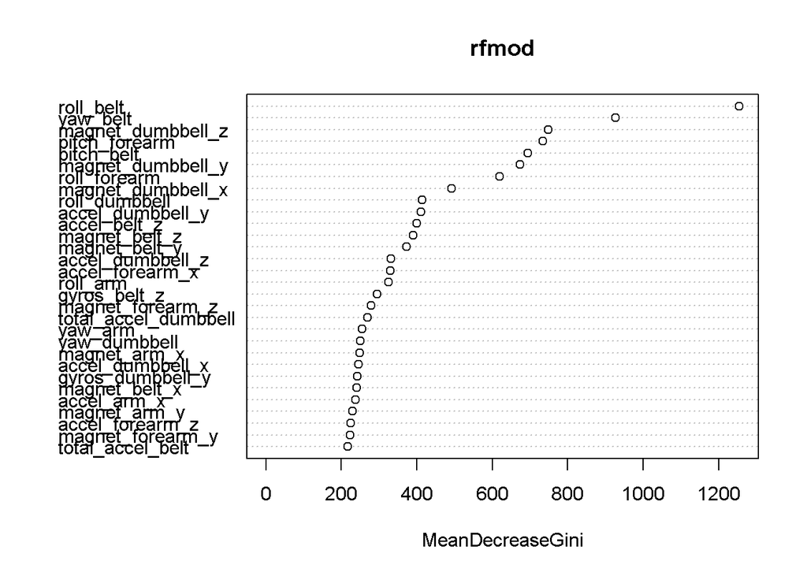

```r
#Investigate what factors are the most important for building the model
varImpPlot(rfmod)
```

The average decrease in GINI (i.e.,the gain of purity of each split variable) is plotted for the top 30 variables. “row_belt” is the highest contributing variable to the classification of the lift position/technique.

#Test data prediction: classification based on Random Forest Model

```r
#Run prediction on test data
predict(rfmod,test)
```

```
##  1  2  3  4  5  6  7  8  9 10 11 12 13 14 15 16 17 18 19 20
##  B  A  B  A  A  E  D  B  A  A  B  C  B  A  E  E  A  B  B  B
## Levels: A B C D E
```

```r
#Calculation of confidence of each prediction
predict(rfmod,test,type="prob")
```

```
##        A     B     C     D     E
## 1  0.036 0.860 0.066 0.018 0.020
## 2  0.936 0.034 0.022 0.002 0.006
## 3  0.104 0.746 0.110 0.000 0.040
## 4  0.944 0.006 0.030 0.020 0.000
## 5  0.974 0.010 0.014 0.002 0.000
## 6  0.004 0.076 0.074 0.014 0.832
## 7  0.014 0.008 0.074 0.884 0.020
## 8  0.058 0.738 0.068 0.108 0.028
## 9  1.000 0.000 0.000 0.000 0.000
## 10 0.992 0.004 0.002 0.002 0.000
## 11 0.052 0.832 0.058 0.038 0.020
## 12 0.012 0.034 0.896 0.016 0.042
## 13 0.002 0.988 0.000 0.002 0.008
## 14 1.000 0.000 0.000 0.000 0.000
## 15 0.000 0.028 0.020 0.020 0.932
## 16 0.012 0.026 0.000 0.014 0.948
## 17 0.980 0.000 0.000 0.000 0.020
## 18 0.034 0.882 0.016 0.058 0.010
## 19 0.068 0.886 0.018 0.022 0.006
## 20 0.002 0.998 0.000 0.000 0.000
## attr(,"class")
## [1] "matrix" "array"  "votes"
```

Problem_ID #3 and #8 show the lowest confidence in prediction (<80%).